# Week 9 · Import a file without losing its meaning

MATH 346 course companion · R

**Note**

Use this chapter with the companion reading guide. **Nothing in this chapter is collected or graded.** The approved syllabus, workload guide and Blackboard remain authoritative.

## Your route

**What must be true before an external table becomes evidence?**

Opening a CSV is only the start. Its names, column types, missing-value conventions and row meaning must match the question. We use six fictional buildings with four monthly measurements and two deliberately unavailable values.

We then change the observation from a building to a building-month. The row count should change, but identifiers, units and missingness must survive. A table can have exactly 24 rows and still lose the information needed to interpret them.

Before you start · Words used here · Setup · Meeting 1 · Meeting 2 · AI audit · Practice and resources · Chapter list. The page contents navigation also links to the sections.

**TipA first 30-minute recovery session**

Choose a stopping point within about 30 minutes; continue from there next time. This is an untested first-pass budget, not a completion promise.

1. Check prerequisites and setup. If access is blocked, focus on that first.
2. Inspect the supplied CSV header and the declared import contract.
3. Read the tidy observation/key explanation and predict six buildings times four months.
4. Inspect the monthly missing/observed counts and try the key self-check. Defer export and extra practice.

Read displayed results when jumping ahead; run complete code in its stated sequence when returning to your script. The full practice selection is Core **1, 3, 4, 5, 6**, selective Guided **2, 7, 9**, and optional Extension **8**, within the **90–120-minute** ordinary-week budget.

### Before you start

You should recognize data frames, numeric/text variables, NA and grouped summaries from Weeks 6–8. No prior external-file import or pivot syntax is assumed. This file is supplied synthetic data; do not collect your own dataset or describe it as actual campus measurement.

Use [software requirements](https://lnajman.github.io/math346/resources/software-requirements.html) and the [course glossary](https://lnajman.github.io/math346/resources/glossary.html) when needed. You do not need a paid AI account or an external AI call: the flawed examples are supplied locally.

**NoteWords used in this chapter**

| Word or pattern | Meaning here |
| --- | --- |
| **CSV** | A text file containing comma-separated fields and a header. |
| **Relative path** | A location such as data/file.csv interpreted from the project folder. |
| **Schema** | Expected field names and column types. |
| **Parsing problem** | A recorded failure to interpret a field according to its declared type. |
| **Missing marker** | A source encoding, here blank or “missing”, declared to mean NA. |
| **Wide / long** | Measurements stored in several columns versus a measurement column and a label variable. |
| **Observation key** | The fields that identify one intended row; after pivoting, building plus month. |
| **Denominator** | The number of observations contributing to a summary. |
| **Round trip** | Export, re-import and recheck the same contract. |

### Read / Explain / Check / Interpret

Read the inputs and operations; explain your prediction; check a specific claim; interpret the result with its domain or units.

Think first; write a private comment only where requested—see the prediction guide.

## Setup

Use the readr, dplyr, tidyr and ggplot2 packages. Save the CSV in `week09/data/` and starters in `week09/`. Set the project folder once; do not use a personal absolute path.

Download the starters first. Keep these files in your working folder: `week09-import-contract.R`; `week09-tidy-energy.R`; `data/week09-campus-energy-wide.csv`. Keep `data/` directly below that folder. Possible solutions are separate comparison files linked below.

- Starter: week09-import-contract.R
- Starter: week09-tidy-energy.R
- AI critique target: week09-ai-tidy-review.R
- Supplied data: week09-campus-energy-wide.csv

Run this before the other blocks; it reports missing paths without changing files.

```r
required_paths <- c("week09-import-contract.R", "week09-tidy-energy.R", "data/week09-campus-energy-wide.csv")
```

```r
missing_paths <- required_paths[!file.exists(required_paths)]
if (length(missing_paths) == 0) {
  cat("Setup OK\n")
} else {
  cat("Missing from the current folder:\n", paste(missing_paths, collapse = "\n"), "\n", sep = "")
}
```

**Example output when all required files are present:**

```
Setup OK
```

This is example output, not confirmation of your computer’s setup. Run the check in your own R session and read that result. Restart R, then run the chapter’s code in order, including the code inside the reference reveals. A successful `stopifnot` is silent; a failed condition stops the script.

## Meeting 1 · Read the computation

Class route: two 75-minute meetings, each with its final five-minute exit.

Before import, read the raw header: building identifier/type, area in m², then January through April energy in kWh. The blank April field and the word “missing” in February both encode unavailable measurements. Requiring no NA anywhere would contradict this source. IDs can require completeness while energy measurements permit documented missingness.

### Declare and enforce an import contract

**Slide cues:** *Use A Relative Path*; *Declare Missing Markers*; *Declare Column Types*; *Inspect Parsing Problems*.

`file.exists` checks the location, not the contents. `read_csv` receives an explicit `na` rule and `cols` specification; `show_col_types = FALSE` only reduces routine output and is not a validation step. The audit prints five quantities, while the later assertions enforce the expected names, count, types, ranges and missingness.

Automatic guessing can accept a whole column as text and therefore report no parsing problems. That is why a zero-row problems table and a numeric-column contract have different jobs. Compare a declaration with the actual source before choosing which values to exclude or recode.

**Predict in a private comment first:** Should the declared import have zero missing measurements or two? Can zero parsing problems alone establish that every monthly column is numeric?

**Compare your reasoning**

The supplied file should contain two missing energy values after import. Zero parsing problems alone is insufficient: text may be valid under a guessed text type. If your answer differed, separate intended missing encodings from failed parsing, and intended types from successful acceptance of any text.

**Try before expanding:** Use Core 1/3 to inspect the source and fill the import/schema checks before opening the reference. Predict which expectation your code would stop on if the wrong file were selected.

**Reference version · week09-import-contract_sol.R**

```r
# MATH 346 - possible worked solution
# Compare only after attempting the starter; other correct implementations are possible.

# MATH 346 - Week 9
# Import an external CSV using an explicit, checked contract

library(dplyr)
library(readr)

data_path <- "data/week09-campus-energy-wide.csv"
stopifnot(file.exists(data_path))

expected_columns <- c(
  "building_id", "building_type", "area_m2",
  "jan_kwh", "feb_kwh", "mar_kwh", "apr_kwh"
)

energy_wide <- read_csv(
  data_path,
  na = c("", "missing"),
  col_types = cols(
    building_id = col_character(),
    building_type = col_character(),
    area_m2 = col_double(),
    jan_kwh = col_double(),
    feb_kwh = col_double(),
    mar_kwh = col_double(),
    apr_kwh = col_double()
  ),
  show_col_types = FALSE
)

parse_issues <- problems(energy_wide)
monthly_columns <- c("jan_kwh", "feb_kwh", "mar_kwh", "apr_kwh")

import_audit <- data.frame(
  quantity = c(
    "rows",
    "columns",
    "unique building identifiers",
    "missing monthly energy values",
    "parsing problems"
  ),
  value = c(
    nrow(energy_wide),
    ncol(energy_wide),
    n_distinct(energy_wide$building_id),
    sum(is.na(energy_wide[monthly_columns])),
    nrow(parse_issues)
  )
)

print(import_audit)
```

```
                       quantity value
1                          rows     6
2                       columns     7
3   unique building identifiers     6
4 missing monthly energy values     2
5              parsing problems     0
```

```r
glimpse(energy_wide)
```

```
Rows: 6
Columns: 7
$ building_id   <chr> "BLDG-01", "BLDG-02", "BLDG-03", "BLDG-04", "BLDG-05", "…
$ building_type <chr> "academic", "library", "laboratory", "residence", "sport…
$ area_m2       <dbl> 4200, 5600, 3900, 6100, 7200, 2800
$ jan_kwh       <dbl> 118000, 152000, 168500, 203000, 241000, 74500
$ feb_kwh       <dbl> 111500, 147500, 165200, NA, 225500, 71200
$ mar_kwh       <dbl> 106200, 143800, 171000, 187500, 218900, 68800
$ apr_kwh       <dbl> 98200, 138200, 169800, 176800, NA, 64200
```

```r
stopifnot(
  identical(names(energy_wide), expected_columns),
  nrow(energy_wide) == 6,
  ncol(energy_wide) == 7,
  n_distinct(energy_wide$building_id) == nrow(energy_wide),
  all(energy_wide$area_m2 > 0),
  all(vapply(energy_wide[monthly_columns], is.double, logical(1))),
  all(unlist(energy_wide[monthly_columns]) > 0, na.rm = TRUE),
  sum(is.na(energy_wide[monthly_columns])) == 2,
  nrow(parse_issues) == 0
)

cat("Week 9 import contract passed.\n")
```

```
Week 9 import contract passed.
```

**Explain / Check / Interpret:** The printed audit should show six rows, seven columns, six unique building identifiers, two missing energy values and zero parsing problems. A Boolean comparison printed as FALSE does not stop later computation; stopifnot enforces it. Checks specific to this teaching file should be investigated if data change, not treated as universal rules about buildings.

### Meeting 1 in-class exit · Final five minutes

Name one import assumption that should become executable code.

Solo readers: use the self-check below; no submission.

### Meeting 1 self-check · No submission

A file opens successfully and shows the word “missing” as ordinary text. Which assumption should become executable code before calculating a mean?

**Compare the Meeting 1 self-check**

Declare “missing” and blank as NA, declare the energy field numeric, and check missing counts/types and parsing diagnostics. The word itself is a source convention to interpret, not an energy measurement or a zero.

## Meeting 2 · Check the claim

One wide row is a building with four monthly cells. One tidy row is one building in one month, so a repeated building ID is expected. Building plus month must be unique. `pivot_longer` takes month values from selected column names and energy values from cells; identifier and area columns remain attached. Tidy structure is defined for a question, not by a table merely looking long.

### Make building-month observations explicit

**Slide cues:** *The Intended Tidy Row*; *`pivot_longer` Pattern*; *Check The Observation Key*; *Keep Denominators*.

`ends_with("_kwh")` selects only measurement columns. `names_pattern` extracts the month prefix; the unit remains in `energy_kwh`. The code adds a month number using `match` so chronological order does not depend on alphabetical sorting. After pivoting, arrange by building and month, then check the key.

Each monthly total uses observed measurements. `na.rm = TRUE` does not impute missing energy or make all months equally complete. The neighboring expected, observed and missing counts keep that limitation visible. The plot labels recorded totals and says the data are synthetic.

**Predict in a private comment first:** Will a unique-building-ID check still pass on the tidy table? Can a 24-row result be wrong even when it has the expected size?

**Compare your reasoning**

Building ID alone repeats four times; building plus month is the new key. A 24-row result could duplicate one building-month and omit another. If your answer differed, you probably carried the wide-table row meaning into the long table or treated a count as proof of identity.

**Try before expanding:** Complete Core 4/5/6: state the output row meaning and expected key, then fill pivot_longer and its key check in the starter.

**Reference version · week09-tidy-energy_sol.R**

```r
# MATH 346 - possible worked solution
# Compare only after attempting the starter; other correct implementations are possible.

# MATH 346 - Week 9
# Reshape the supplied campus-energy data and validate its observation key

library(dplyr)
library(ggplot2)
library(readr)
library(tidyr)

data_path <- "data/week09-campus-energy-wide.csv"
stopifnot(file.exists(data_path))

energy_wide <- read_csv(
  data_path,
  na = c("", "missing"),
  col_types = cols(
    building_id = col_character(),
    building_type = col_character(),
    area_m2 = col_double(),
    jan_kwh = col_double(),
    feb_kwh = col_double(),
    mar_kwh = col_double(),
    apr_kwh = col_double()
  ),
  show_col_types = FALSE
)

month_order <- c("jan", "feb", "mar", "apr")

energy_tidy <- energy_wide |>
  pivot_longer(
    cols = ends_with("_kwh"),
    names_to = "month",
    names_pattern = "(.*)_kwh",
    values_to = "energy_kwh"
  ) |>
  mutate(month_number = match(month, month_order)) |>
  arrange(building_id, month_number) |>
  select(
    building_id, building_type, area_m2,
    month, month_number, energy_kwh
  )

key_counts <- energy_tidy |>
  count(building_id, month, name = "key_count")

monthly_summary <- energy_tidy |>
  group_by(month, month_number) |>
  summarize(
    expected_buildings = n(),
    observed_buildings = sum(!is.na(energy_kwh)),
    missing_buildings = sum(is.na(energy_kwh)),
    total_energy_kwh = sum(energy_kwh, na.rm = TRUE),
    .groups = "drop"
  ) |>
  arrange(month_number)

print(energy_tidy)
```

```
# A tibble: 24 × 6
   building_id building_type area_m2 month month_number energy_kwh
   <chr>       <chr>           <dbl> <chr>        <int>      <dbl>
 1 BLDG-01     academic         4200 jan              1     118000
 2 BLDG-01     academic         4200 feb              2     111500
 3 BLDG-01     academic         4200 mar              3     106200
 4 BLDG-01     academic         4200 apr              4      98200
 5 BLDG-02     library          5600 jan              1     152000
 6 BLDG-02     library          5600 feb              2     147500
 7 BLDG-02     library          5600 mar              3     143800
 8 BLDG-02     library          5600 apr              4     138200
 9 BLDG-03     laboratory       3900 jan              1     168500
10 BLDG-03     laboratory       3900 feb              2     165200
# ℹ 14 more rows
```

```r
print(monthly_summary)
```

```
# A tibble: 4 × 6
  month month_number expected_buildings observed_buildings missing_buildings
  <chr>        <int>              <int>              <int>             <int>
1 jan              1                  6                  6                 0
2 feb              2                  6                  5                 1
3 mar              3                  6                  6                 0
4 apr              4                  6                  5                 1
# ℹ 1 more variable: total_energy_kwh <dbl>
```

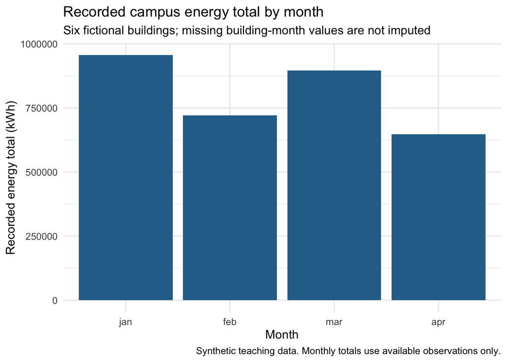

```r
stopifnot(
  nrow(energy_tidy) == 24,
  ncol(energy_tidy) == 6,
  n_distinct(energy_tidy$building_id) == 6,
  identical(sort(unique(energy_tidy$month_number)), 1:4),
  !anyNA(energy_tidy$month_number),
  all(energy_tidy$energy_kwh > 0, na.rm = TRUE),
  all(key_counts$key_count == 1),
  nrow(key_counts) == nrow(energy_tidy),
  sum(is.na(energy_tidy$energy_kwh)) == 2,
  nrow(monthly_summary) == 4,
  all(monthly_summary$expected_buildings == 6),
  sum(monthly_summary$missing_buildings) == 2,
  all(monthly_summary$observed_buildings +
    monthly_summary$missing_buildings == 6)
)

monthly_plot <- ggplot(
  monthly_summary,
  aes(x = reorder(month, month_number), y = total_energy_kwh)
) +
  geom_col(fill = "#2A6F97") +
  labs(
    title = "Recorded campus energy total by month",
    subtitle = "Six fictional buildings; missing building-month values are not imputed",
    x = "Month",
    y = "Recorded energy total (kWh)",
    caption = "Synthetic teaching data. Monthly totals use available observations only."
  ) +
  theme_minimal(base_size = 12)

plot_data <- ggplot_build(monthly_plot)$data[[1]]
stopifnot(nrow(plot_data) == nrow(monthly_summary))

print(monthly_plot)
```

```r
cat("Week 9 tidy-data checks passed.\n")
```

```
Week 9 tidy-data checks passed.
```

**Explain / Check / Interpret:** The result has 24 rows and six columns, retains two NAs, and contains exactly one row per building-month. The monthly summary has four rows with six expected buildings each. Check that observed plus missing equals six per month. The export/re-import task stays optional Extension 8; when selected, recheck names, types, key and missingness after reading the saved file.

## AI audit · Inspect before accepting

**Slide cues:** *Plausible AI Reshape*; *Why It Is Not Trustworthy*; *Repair Order*.

This is **selective Guided practice**; use it when selected or helpful.

Read the supplied target and choose a check before opening the diagnosis. No AI service is contacted.

Before running the supplied flawed reshape, choose checks for retained building_id, retained area, numeric energy, separated month/unit and an observation key. Its own count check is deliberately weak. Inspect its `values_transform` and final `select` before reading its printed diagnosis.

**Reading excerpt:** this fragment relies on the supplied script setup; inspect it here, then run the complete file in the evidence reveal.

```r
ai_tidy <- ai_import |>
  pivot_longer(
    cols = jan_kwh:apr_kwh,
    names_to = "measurement",
    values_to = "energy_kwh",
    values_transform = list(energy_kwh = as.character)
  ) |>
  select(building_type, measurement, energy_kwh)
```

**Predict in a private comment first:** Why can the generated table pass a 24-row assertion while being unusable for a building-level energy-intensity question?

**Compare your reasoning**

It converts energy to text and selects away both building_id and area. The `measurement` label still contains names such as jan_kwh. There is no traceable building-month key and no area for an intensity calculation. Repair the import first, then reshape only measurements while retaining context. If your answer differed, count verification probably displaced checks of type, identity, units and the actual question.

**Run the complete supplied critique target and inspect the evidence**

```r
# MATH 346 - Week 9
# AI tidy-data critique starter
#
# The generated result has 24 rows, but it loses the observation key and keeps
# energy values as character text.

library(dplyr)
library(readr)
library(tidyr)

data_path <- "data/week09-campus-energy-wide.csv"
stopifnot(file.exists(data_path))

ai_import <- read_csv(data_path, show_col_types = FALSE)

ai_tidy <- ai_import |>
  pivot_longer(
    cols = jan_kwh:apr_kwh,
    names_to = "measurement",
    values_to = "energy_kwh",
    values_transform = list(energy_kwh = as.character)
  ) |>
  select(building_type, measurement, energy_kwh)

print(ai_tidy)
```

```
# A tibble: 24 × 3
   building_type measurement energy_kwh
   <chr>         <chr>       <chr>
 1 academic      jan_kwh     118000
 2 academic      feb_kwh     111500
 3 academic      mar_kwh     106200
 4 academic      apr_kwh     98200
 5 library       jan_kwh     152000
 6 library       feb_kwh     147500
 7 library       mar_kwh     143800
 8 library       apr_kwh     138200
 9 laboratory    jan_kwh     168500
10 laboratory    feb_kwh     165200
# ℹ 14 more rows
```

```r
stopifnot(
  nrow(ai_tidy) == 24,
  is.character(ai_tidy$energy_kwh),
  !"building_id" %in% names(ai_tidy),
  !"area_m2" %in% names(ai_tidy)
)

cat("The generated reshape runs and returns 24 rows.\n")
```

```
The generated reshape runs and returns 24 rows.
```

```r
cat("It drops the building identifier and area, fuses month with the unit, and stores energy as text.\n")
```

```
It drops the building identifier and area, fuses month with the unit, and stores energy as text.
```

```r
# Review questions:
# 1. What should one tidy row represent?
# 2. Which variables form the observation key?
# 3. Why must energy_kwh be numeric?
# 4. Which columns were discarded even though later questions may need them?
# 5. How should the month names be separated from the _kwh unit suffix?
# 6. Which checks would detect duplicated or missing building-month keys?
```

Use the existing AI policy when assistance is used: explain every accepted line and keep the requested evidence with your existing work. A passing test never replaces checking whether the code answers the actual question.

### Meeting 2 in-class exit · Final five minutes

A table is tidy and trustworthy for a question when …

Solo readers: use the self-check below; no submission.

### Meeting 2 self-check · No submission

Close earlier reveals and explain from memory: After a correct pivot, BLDG-01 appears four times. Is that sufficient evidence of a duplicate observation? Name the check that matches the new unit.

**Compare the Meeting 2 self-check**

No. Four rows are expected, one per month. Count by building_id and month; each pair should occur once, with all expected months present. Row meaning explains why a valid wide-table uniqueness rule must change after pivoting.

## Practice, recovery and resources

**Core:** 1, 3, 4, 5, 6. **Guided:** 2, 7, 9. **Extension:** 8.

Core 1/3 concern source inspection and import; Core 4/5 define and create the tidy unit; Core 6 checks its key. Guided 7 adds incomplete-month summaries and Guided 9 audits AI structure. Exercise 8 export is Extension. Keep this selection when using the main lab.

Attempt the selected starter blocks before comparing possible solutions. TODO comments are placeholders, not completed analysis. Keep your checked script and follow Blackboard if a checkpoint is requested.

**If you are stuck:** inspect the file path, schema, missing markers, and observation key. Run missing definitions before their first use. Keep the first error and ask for help if a focused attempt remains blocked.

- Possible solution: week09-import-contract_sol.R
- Possible solution: week09-tidy-energy_sol.R

**Where this fits:** [Week 9 notes](https://lnajman.github.io/math346/weeks/week-09.html) · [Matching slides](https://lnajman.github.io/math346/slides/week-09.html) · [Main lab](https://lnajman.github.io/math346/labs/lab-09-import-tidy-data.html) · [AI-review lab](https://lnajman.github.io/math346/labs/lab-09-ai-tidy-review.html) · [Exercises](https://lnajman.github.io/math346/weeks/week-09-exercises.html).